# Instacart Exploratory Analysis

Instacart is an app to send somebody else to shop for you.

```r
source("readDataToMemory.R")
```

```
## * Using Spark: 2.1.0
```

```r
readInstacart()

library(DBI)
library(ggplot2)
library(ggthemes)

src_tbls(sc)
```

```
## [1] "order_products__prior_tbl" "order_products__train_tbl"
## [3] "orders_tbl"                "products_tbl"
```

```
select ~ SELECT
filter ~ WHERE
arrange ~ ORDER
summarise ~ aggregators: sum, min, sd, etc.
mutate ~ operators: +, *, log, etc.
```

### Order products

`order_products__*.csv`

These files specify which products were purchased in each order.

- order_id : id of the order
- product_id : id of the product
- add_to_cart_order : order in which the product was added to the cart
- reordered : if the product has been purchased before

```
SELECT  --- name of columns
FROM    --- name of table
WHERE   --- conditions
```

```r
dbGetQuery(sc, "SELECT * FROM order_products__prior_tbl LIMIT 10")
```

```
##    order_id product_id add_to_cart_order reordered
## 1         2      33120                 1         1
## 2         2      28985                 2         1
## 3         2       9327                 3         0
## 4         2      45918                 4         1
## 5         2      30035                 5         0
## 6         2      17794                 6         1
## 7         2      40141                 7         1
## 8         2       1819                 8         1
## 9         2      43668                 9         0
## 10        3      33754                 1         1
```

## orders

`orders.csv`

This file tells to which set (prior, train, test) an order belongs.

```r
orders_prev <- dbGetQuery(sc, "SELECT * FROM orders_tbl LIMIT 100")
orders_prev
```

```
##     order_id user_id eval_set order_number order_dow order_hour_of_day
## 1    2539329       1    prior            1         2                 8
## 2    2398795       1    prior            2         3                 7
## 3     473747       1    prior            3         3                12
## 4    2254736       1    prior            4         4                 7
## 5     431534       1    prior            5         4                15
## 6    3367565       1    prior            6         2                 7
## 7     550135       1    prior            7         1                 9
## 8    3108588       1    prior            8         1                14
## 9    2295261       1    prior            9         1                16
## 10   2550362       1    prior           10         4                 8
## 11   1187899       1    train           11         4                 8
## 12   2168274       2    prior            1         2                11
## 13   1501582       2    prior            2         5                10
## 14   1901567       2    prior            3         1                10
```

[output cut: 187 more lines]

How many different products there are?

Example of data aggregation

```r
dbGetQuery(
  sc,
  "
SELECT COUNT(DISTINCT product_id) AS products
FROM order_products__prior_tbl
  "
  )
```

```
##   products
## 1    49677
```

How many times a product was purchased?

```r
products_popularity_txt <- "
SELECT product_id
,   COUNT(1) AS n_orders
FROM order_products__prior_tbl
GROUP BY product_id
ORDER BY n_orders DESC
LIMIT 50
"

products_popularity <-
  dbGetQuery(sc, products_popularity_txt)

products_popularity
```

```
##    product_id n_orders
## 1       24852   472565
## 2       13176   379450
## 3       21137   264683
## 4       21903   241921
## 5       47209   213584
## 6       47766   176815
## 7       47626   152657
## 8       16797   142951
## 9       26209   140627
## 10      27845   137905
## 11      27966   137057
## 12      22935   113426
## 13      24964   109778
## 14      45007   104823
```

[output cut: 36 more lines]

## Products

`products.csv`

```r
dbGetQuery(sc, "SELECT * FROM products_tbl LIMIT 20")
```

```
##    product_id
## 1           1
## 2           2
## 3           3
## 4           4
## 5           5
## 6           6
## 7           7
## 8           8
## 9           9
## 10         10
## 11         11
## 12         12
## 13         13
## 14         14
```

[output cut: 48 more lines]

## Joins

Merge both datasets to get product name and product id, and number of times a product was purchased.

```r
products_popularity_txt <- "
SELECT op.product_id
,   n_orders
,   product_name
FROM (
    SELECT product_id
    ,   COUNT(1) AS n_orders
    FROM order_products__prior_tbl
    GROUP BY product_id
    ORDER BY n_orders DESC
    LIMIT 30) op
LEFT JOIN (
    SELECT product_id
    ,   product_name
    FROM products_tbl) p
ON op.product_id = p.product_id
"

products_popularity <-
  dbGetQuery(sc, products_popularity_txt)

products_popularity
```

```
##    product_id n_orders                         product_name
## 1       24852   472565                               Banana
## 2       13176   379450               Bag of Organic Bananas
## 3       21137   264683                 Organic Strawberries
## 4       21903   241921                 Organic Baby Spinach
## 5       47209   213584                 Organic Hass Avocado
## 6       47766   176815                      Organic Avocado
## 7       47626   152657                          Large Lemon
## 8       16797   142951                         Strawberries
## 9       26209   140627                                Limes
## 10      27845   137905                   Organic Whole Milk
## 11      27966   137057                  Organic Raspberries
## 12      22935   113426                 Organic Yellow Onion
## 13      24964   109778                       Organic Garlic
## 14      45007   104823                     Organic Zucchini
```

[output cut: 16 more lines]

Make a barplot of product popularity, sorted by product popularity.

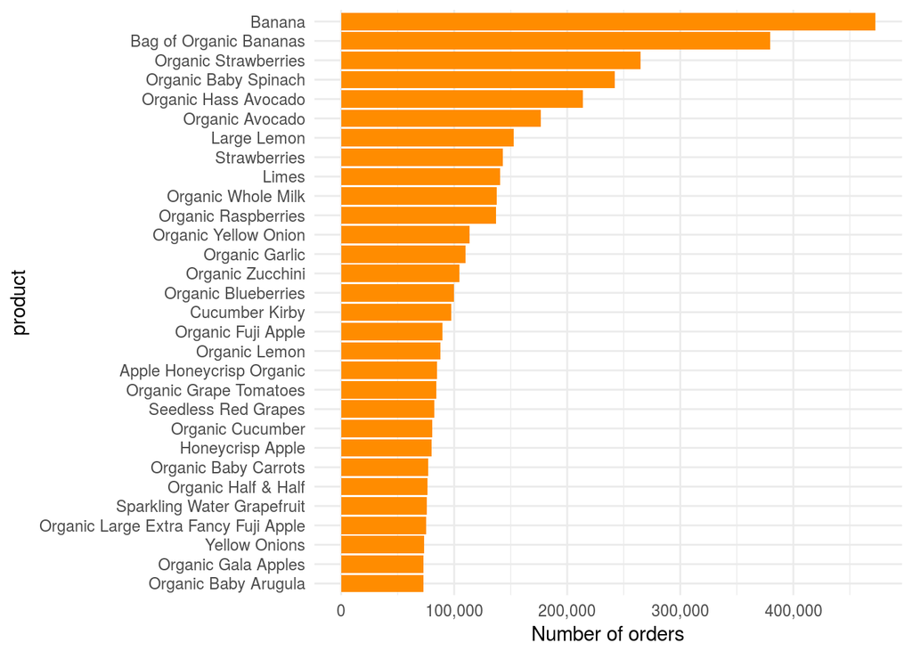

```r
products_popularity %>%
  ggplot(
    aes(reorder(product_name, n_orders, function(x) x),
        n_orders)) +
  geom_bar(stat="identity", fill='darkorange') +
  coord_flip() +
  scale_y_continuous(label=scales::comma) +
  xlab("product") +
  ylab("Number of orders") +
  theme_minimal()
```

```r
products_popularity_txt <- "
SELECT op.product_id
,   n_orders
,   product_name
FROM (
    SELECT product_id
    ,   COUNT(1) AS n_orders
    FROM order_products__prior_tbl
    GROUP BY product_id
    ORDER BY n_orders DESC
    LIMIT 30) op
LEFT JOIN (
    SELECT product_id
    ,   product_name
    FROM products_tbl) p
ON op.product_id = p.product_id
"

products_popularity <-
  dbGetQuery(sc, products_popularity_txt)

products_popularity
```

```
##    product_id n_orders                         product_name
## 1       24852   472565                               Banana
## 2       13176   379450               Bag of Organic Bananas
## 3       21137   264683                 Organic Strawberries
## 4       21903   241921                 Organic Baby Spinach
## 5       47209   213584                 Organic Hass Avocado
## 6       47766   176815                      Organic Avocado
## 7       47626   152657                          Large Lemon
## 8       16797   142951                         Strawberries
## 9       26209   140627                                Limes
## 10      27845   137905                   Organic Whole Milk
## 11      27966   137057                  Organic Raspberries
## 12      22935   113426                 Organic Yellow Onion
## 13      24964   109778                       Organic Garlic
## 14      45007   104823                     Organic Zucchini
```

[output cut: 16 more lines]

## Questions

- Which day of week people order most fequently?

```r
day_popularity_txt <- "
SELECT order_dow
,   COUNT(1) AS n_orders_day
FROM orders_tbl
GROUP BY order_dow
ORDER BY n_orders_day DESC
"

day_popularity <-
  dbGetQuery(sc, day_popularity_txt)

day_popularity
```

```
##   order_dow n_orders_day
## 1         0       600905
## 2         1       587478
## 3         2       467260
## 4         5       453368
## 5         6       448761
## 6         3       436972
## 7         4       426339
```

- The most popular hour of doing order?

```r
hour_popularity_txt <- "
SELECT order_hour_of_day
,   COUNT(1) AS n_orders_hour
FROM orders_tbl
GROUP BY order_hour_of_day
ORDER BY n_orders_hour DESC
LIMIT 10
"

hour_popularity <-
  dbGetQuery(sc, hour_popularity_txt)

hour_popularity
```

```
##    order_hour_of_day n_orders_hour
## 1                 10        288418
## 2                 11        284728
## 3                 15        283639
## 4                 14        283042
## 5                 13        277999
## 6                 12        272841
## 7                 16        272553
## 8                  9        257812
## 9                 17        228795
## 10                18        182912
```

- The most reordered products?

```r
# which products were reordered?

reordered_products_txt <- "
SELECT product_id
FROM order_products__prior_tbl
WHERE reordered = 1
LIMIT 10
"

reordered_products <-
  dbGetQuery(sc, reordered_products_txt)

reordered_products
```

```
##    product_id
## 1       33120
## 2       28985
## 3       45918
## 4       17794
## 5       40141
## 6        1819
## 7       33754
## 8       24838
## 9       17704
## 10      21903
```

```r
### not sure this is right! got the same result as most popular product
reordered_products_popularity_txt <- "
SELECT op.product_id
,   n_orders
,   product_name
FROM (
    SELECT product_id
    ,   COUNT(1) AS n_orders
    FROM order_products__prior_tbl
    WHERE reordered = 1
    GROUP BY product_id
    ORDER BY n_orders DESC
    LIMIT 30) op
LEFT JOIN (
    SELECT product_id
    ,   product_name
    FROM products_tbl) p
ON op.product_id = p.product_id
"

reordered_products_popularity <-
  dbGetQuery(sc, reordered_products_popularity_txt)

reordered_products_popularity
```

```
##    product_id n_orders                         product_name
## 1       24852   398609                               Banana
## 2       13176   315913               Bag of Organic Bananas
## 3       21137   205845                 Organic Strawberries
## 4       21903   186884                 Organic Baby Spinach
## 5       47209   170131                 Organic Hass Avocado
## 6       47766   134044                      Organic Avocado
## 7       27845   114510                   Organic Whole Milk
## 8       47626   106255                          Large Lemon
## 9       27966   105409                  Organic Raspberries
## 10      16797    99802                         Strawberries
## 11      26209    95768                                Limes
## 12      22935    79072                 Organic Yellow Onion
## 13      24964    74663                       Organic Garlic
## 14      45007    72165                     Organic Zucchini
```

[output cut: 16 more lines]

- The less reorderd product?

```r
reordered_products_popularity_txt <- "
SELECT op.product_id
,   n_orders
,   product_name
FROM (
    SELECT product_id
    ,   COUNT(1) AS n_orders
    FROM order_products__prior_tbl
    WHERE reordered = 1
    GROUP BY product_id
    ORDER BY n_orders ASC
    LIMIT 30) op
LEFT JOIN (
    SELECT product_id
    ,   product_name
    FROM products_tbl) p
ON op.product_id = p.product_id
"

reordered_products_popularity <-
  dbGetQuery(sc, reordered_products_popularity_txt)

reordered_products_popularity
```

```
##    product_id n_orders                                        product_name
## 1        4435        1                           Shoga Gari Pickled Ginger
## 2       20963        1              1 Step-1 Minute Noodles Toasted Sesame
## 3        2682        1                                    Rosy Lip Therapy
## 4        2873        1                              Vanilla Macadamia Milk
## 5        4144        1                          Optive Lubricant Eye Drops
## 6        9260        1                                     Ginger, Pickled
## 7       11721        1 Purely Natural Hand-Flaked Salmon Treats Cat Treats
## 8       23298        1                          Ice Cream Cake Celebration
## 9       41848        1                            Carousel Party Sprinkles
## 10      36382        1                    Fish Oil With Vitamin D Softgels
## 11       1899        1                                  Mini Carrots Bunch
## 12      29560        1                    Sleek & Shine Fortifying Shampoo
## 13      31475        1                                Organic Millet Flour
## 14      42065        1          Water Enhancer, Stevia, Raspberry Lemonade
```

[output cut: 16 more lines]

- Plot histogram of number of products in an order.

```r
####
number_products_order_txt <- "
SELECT order_id
,   COUNT(1) AS n_orders
FROM order_products__prior_tbl
GROUP BY order_id
ORDER BY n_orders DESC
LIMIT 50
"

number_products_order <-
  dbGetQuery(sc, number_products_order_txt)

number_products_order
```

[output not shown]

- What is the most popular department?

## Whisker, magrittr

```r
library(whisker)
library(magrittr)

product_times_ordered_txt <- "
SELECT n_orders
,   COUNT(DISTINCT user_id) AS n_users
FROM (
    SELECT o.user_id
    ,   COUNT(DISTINCT op.order_id) AS n_orders
    FROM (
        SELECT order_id
        FROM order_products__prior_tbl
        WHERE product_id = {{productId}}
    ) op
    LEFT JOIN (
        SELECT  user_id
        ,   order_id
        FROM orders_tbl) o
    ON op.order_id = o.order_id
    GROUP BY o.user_id) opo
GROUP BY n_orders
ORDER BY n_orders
"

data <- list(productId = 24852)

product_times_ordered_txt %>%
  whisker.render(data) %>%
  cat
```

```
##
## SELECT n_orders
## ,   COUNT(DISTINCT user_id) AS n_users
## FROM (
##     SELECT o.user_id
##     ,   COUNT(DISTINCT op.order_id) AS n_orders
##     FROM (
##         SELECT order_id
##         FROM order_products__prior_tbl
##         WHERE product_id = 24852
##     ) op
##     LEFT JOIN (
##         SELECT  user_id
##         ,   order_id
##         FROM orders_tbl) o
##     ON op.order_id = o.order_id
##     GROUP BY o.user_id) opo
## GROUP BY n_orders
## ORDER BY n_orders
```

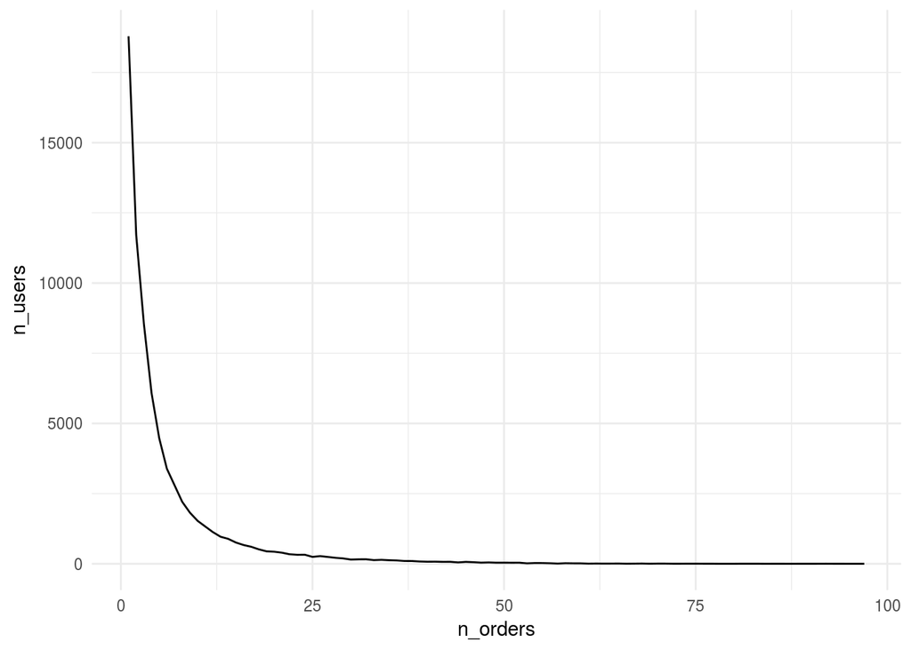

```r
product_times_ordered_txt %>%
  whisker.render(data) %>%
  dbGetQuery(sc, .) %>%
  ggplot(aes(n_orders, n_users)) +
  geom_line() +
  theme_minimal()
```

## Questions

- For given department, plot the most popular product (with templating department).
- For given day, rank department popularity.

## More on orders (Window Functions)

```r
dbGetQuery(sc,
"
SELECT days_since_prior_order
,   COUNT(1) AS N
FROM orders_tbl
GROUP BY days_since_prior_order
")
```

```
##    days_since_prior_order      N
## 1                      14 100230
## 2                      13  83214
## 3                      27  22013
## 4                       6 240013
## 5                      12  76146
## 6                       7 320608
## 7                      25  19234
## 8                      28  26777
## 9                       0  67755
## 10                     10  95186
## 11                     18  35881
## 12                    NaN 206209
## 13                     19  34384
## 14                     20  38527
```

[output cut: 18 more lines]

```r
dbGetQuery(sc,
"SELECT *
FROM orders_tbl
WHERE user_id <= 10
")
```

```
##    order_id user_id eval_set order_number order_dow order_hour_of_day
## 1   2539329       1    prior            1         2                 8
## 2   2398795       1    prior            2         3                 7
## 3    473747       1    prior            3         3                12
## 4   2254736       1    prior            4         4                 7
## 5    431534       1    prior            5         4                15
## 6   3367565       1    prior            6         2                 7
## 7    550135       1    prior            7         1                 9
## 8   3108588       1    prior            8         1                14
## 9   2295261       1    prior            9         1                16
## 10  2550362       1    prior           10         4                 8
## 11  1187899       1    train           11         4                 8
## 12  2168274       2    prior            1         2                11
## 13  1501582       2    prior            2         5                10
## 14  1901567       2    prior            3         1                10
```

[output cut: 165 more lines]

```r
x <- dbGetQuery(sc,
"SELECT *
FROM order_products__prior_tbl
WHERE product_id = 13176
")

sum(x$reordered)
```

```
## [1] 315913
```

```r
#398609
#315913
21137
```

```
## [1] 21137
```

```r
dbGetQuery(sc,
"SELECT user_id
,   order_id
,   FIRST_VALUE(order_id)  OVER(partition by user_id ORDER BY order_number) AS first_order
FROM orders_tbl
WHERE user_id <= 10
")
```

```
##    user_id order_id first_order
## 1        6  2086598     2086598
## 2        6   298250     2086598
## 3        6   998866     2086598
## 4        6  1528013     2086598
## 5        9   280530      280530
## 6        9  2762092      280530
## 7        9  1830137      280530
## 8        9  1094988      280530
## 9        2  2168274     2168274
## 10       2  1501582     2168274
## 11       2  1901567     2168274
## 12       2   738281     2168274
## 13       2  1673511     2168274
## 14       2  1199898     2168274
```

[output cut: 75 more lines]